# Notes on practical statistics II

# 1 Rules of Thumb for Experimental Data

It is very difficult, in general, to say anything about the amount of data you will need to be able to say something about the mean of a particular quantity, for example. We can, however, give some general rules of thumb, which will be handy:

- **To say *anything* about the mean**, make at least $n = 6$ measurements and preferably $n=10$: the reason for 6 is that this is the minimum number of observations necessary to determine whether something is statistically significant using non-parametric analysis. Joe Howard gives the following example: ‘If one tosses a (fair) coin 6 times, then there is a 1/64 chance that it is heads each time and a 1/64 chance that it is tails each time. Therefore, if you toss a coin 6 times there is only a 1/32 chance (~3%) that it will always be heads or always tails. In other words, if you toss a coin 6 times and it is always heads or tails then you can conclude at the 95% confidence level (actually 97%) that the coin is not fair. Note that the 3% (1/32) is the chance of having a fair coin and getting a false positive, meaning a result that appears to contradict reality’;
- **To say something about the variance**, have at least $n = 30$ data points: this is because, for a normal distribution, the **standard error of the standard deviation** is $\approx\frac{\sigma}{\sqrt{2(n-1)}}$ (see [Ahn et al, 2003](http://web.eecs.umich.edu/~fessler/papers/files/tr/stderr.pdf)) so that, if you have 30 data points, then your **standard error of the standard deviation** is $\approx 13$% of $\sigma$, or nearly an order of magnitude less than it;
- **To say anything about the actual distribution**, have at least $n = 100$ data points. This is really motivatable by considering the **standard error of skewness** and **standard error of kurtosis**, about which you can find more [here](http://estatistics.eu/what-is-statistics-standard-error-of-skewness-standard-error-of-kurtosis/).

These are incredibly generic rules. Keep them in mind and re-evaluate them again & again when you get your data!

# 2 Statistical Hypothesis Testing: An Intuition

Two key aspects of practical statistics are:

- statistical hypothesis testing;
- model fitting (parameter estimation) & model selection.

In this Workshop, we will deal with the first aspect, statistical hypothesis testing.

First: what is an hypothesis? Five examples are:

- The speed of light in a vacuum is 299,792,458 m/s;
- The mean height of adult men in Australia is 175cm;
- The average speed of vesicles along microtubules (in *S. pombe*) is $0.5 \mu m/s$;
- Drug A improves the sleep quality of people who suffer from insomnia;
- An advertisement at the top of my website generates more clicks than one at the bottom of my website.

Definition (Oxford Dictionary, online): an hypothesis “[a] supposition or proposed explanation made on the basis of limited evidence as a starting point for further investigation.”

Now: what is statistical hypothesis testing? It is merely testing how likely an hypothesis is, given the data at hand.

# 3 Essential question: is my data normally distributed?

Some statisticians and physicists would balk at this question. They would correctly tell you that no data is normally distributed, but some is so close to being normally distributed that it is not statistically different to a normal distribution.

So the question becomes: is the data approximately normally distributed? A robust, quantitative way of thinking about this is to perform one or more of a number of hypothesis tests, which we’ll get to, but first, let’s consider it visually with the aid of **Q-Q plots**, short for quantile-quantile plots.

## 3.1 Visual test for normality: Q-Q plots

In order to define a Q-Q plot, we first need to define a *quantile*:

**Definition**: a *quantile* of a data set is the value below which a given percent (or fraction) of the data are: for example, the 10% quantile (also known as the *first decile*) is the value below which 10% of the data are; similarly, the 25% quantile (or the *first quartile* $Q_1$), the 50% quantile (the *second quartile* $Q_2$ or the *median*) and the 75% quantile (or the *third quartile* $Q_3$) are the values below which 1/4, 1/2 and 3/4 of the data are, respectively.

Now all that a Q-Q plot is is a plot of the quantiles of one set of data against the quantiles of another. Below are two examples. The first is the (quantiles of) data generated from a normal distribution plotted against (quantiles of) a theoretic normal distribution. In the second, the data is from a Caunchy distribution (symmetric and with a *heavier tail* than a Gaussian) plotted against a theoretic normal distribution.

First we plot the probability distribution functions of a Gaussian ($\mu = 0 , \sigma = 1$) and a [Cauchy](https://en.wikipedia.org/wiki/Cauchy_distribution) (location $= 0$, scale $=1$) distribution to get a sense of what *heavier tail* means:

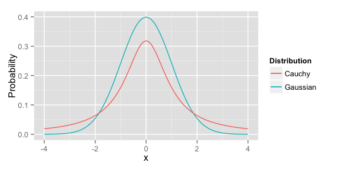

Now let’s look at the Q-Q plots:

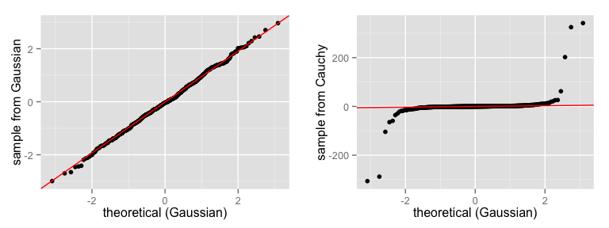

```r
set.seed( 42 )
library( ggplot2 )
source("multiplot.R")
source("qqplot.R")
n <- 500
x <- rnorm( n )
y <- rcauchy( n )
z <- rnorm(100)
p1 <- qqplot.data( x ) + xlab("theoretical (Gaussian)") + ylab("sample from Gaussian")
p2 <- qqplot.data( y ) + xlab("theoretical (Gaussian)") + ylab("sample from Cauchy")
multiplot(p1, p2, cols=2)
```

**Notes**:

- You can distinctly see the heavier tail of the Cauchy distribution here!
- You can also plot histograms to test the normality hypothesis by eye.

These methods give a visual sense of how to test for normality but often we will require methods that are statistically robust. This is where hypothesis testing comes in.

## 3.2 Hypothesis test for normality: the Lilliefors test

The Lilliefors test for normality tests whether any given dataset is statistically different from a normal distribution. It is a particular case of the Kolmogorov-Smirnov test (we won’t cover this here but do check it out because it is one of the great statistical tests!). Given a dataset $D =\{ x_i \}$, of size $n$, we wish to test the **null hypothesis**

$H_0: D \text{ is drawn from a normal distribution.}$

Then the **alternative hypothesis** is $H_1: D \text{ is NOT drawn from a normal distribution.}$

To test the **null hypothesis**,

1. We compare the cumulative distribution functions of $D$ and the normal distribution with mean $\mu_X$ & variance $\sigma_X^2$. To do so we calculate the largest distance $D_{max}$ between them;
2. If the null hypothesis is true, then $D_{max}$ will be drawn from a **Lilliefors distribution** (the distribution itself will depend on the sample size $n$; there are tables, along with more recent analytic approximations, for those interested: http://www.jstor.org/stable/2684607);
3. Using this Lilliefors distribution, we calculate $p$, the probability of seeing $D_{max}$, given the null hypothesis $H_0$, that is, the assumption of normality. Classically, $p$ has been called the $p$-value.
4. If $p<\alpha,$ we can conclude with $(1-\alpha)$ confidence that $D$ was not drawn from a normal distribution. Classically, it is required that $\alpha = 0.05$, in which case we can conclude with 95% confidence that $D$ was not drawn from a normal distribution.

Here we plot the empirical CDFs of a Cauchy and a Gaussian distribution: can you tell which is which? Once could also plot each separately against a theoretical Gaussian in order to visually make sense of the distance $D_{max}$.

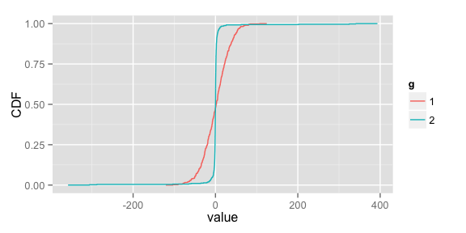

Performing the Lilliefors test in R is super-straightforward:

```r
#http://www.inside-r.org/packages/cran/nortest/docs/lillie.test
library(nortest)#load the necessary library
lillie.test(x) #Lilliefors test for dataset x
```

```
##
##  Lilliefors (Kolmogorov-Smirnov) normality test
##
## data:  x
## D = 0.03246, p-value = 0.2264
```

```r
lillie.test(y) #Lilliefors test for dataset y
```

```
##
##  Lilliefors (Kolmogorov-Smirnov) normality test
##
## data:  y
## D = 0.3785, p-value < 2.2e-16
```

Thus, as the $p$-value for $y$ is less than $10^{-3}$, we can conclude with $>99.9$% confidence that $y$ was NOT drawn from a normal distribution (and phew! as we generated $y$ from a Cauchy distribution). Moreover, as the $p$-value for $x$ was $>0.2$, we cannot conclude with any credible confidence that it was not drawn from a normal distribution (this is also a sanity check).

For more cool approaches to test normality (thinking about skewness, kurtosis; other statistical tests, such as Shapiro-Walk and Anderson-Darling, see [here](http://statsthewayilikeit.com/about/is-my-data-normally-distributed/).

**Exercise 1 (~15 minutes):**

Using one of the following datasets loaded/generated in the code chunks below, do the following (dataset 1: house fly wing lengths; dataset 2: previously generated data that we claimed to be *Gaussian* in order to demonstrate the Central Limit Theorem):

1. Plot the Q-Q-plot and discuss what it tells you;
2. perform a Lilliefors test on the data and interpret the result.

```r
#following data from here: http://www.seattlecentral.edu/qelp/sets/057/057.html
data <-read.table("house_fly_wing_lengths.txt")
```

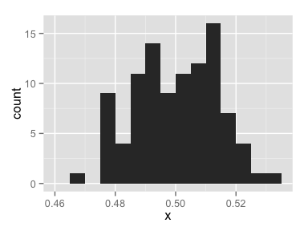

```r
##Here we perform a simple demonstration of the Central Limit Theorem
##Random Variable defined by p(0)=p(1)=0.5. Draw n samples (e.g. n = 1000)
##& retrieve the mean. Do this m times (e.g. m = 10,000) and plot
##the distribution of means:
n <- 1000 #number of samples for each trial
m <- 100 #number of trials
x <- rbinom( m , n , 0.5 )/n # sample distribution and return vector of means
qplot(x , binwidth = 0.005) #plot histogram of means
```

# 4 Student’s t-tests

The Student’s t-tests pervades biology, in particular, and the statistical sciences, in general: it is generally used to see whether the effect seen in an experiment, when compared with a control, is statistically significant.

## 4.1 One sample t-test

I am measuring a quantity in an experiment (e.g., a mutant) for which there is a control. This quantity has a specific value $\mu$ and my measurement process has a normal error (e.g., amount of protein using a fluorospectrometer). Let $x_1,x_2,\ldots,x_n$ be $n$ independent samples: this means that they will be drawn from the distribution $N( \mu , \sigma^2)$. We want to answer the question: is the amount $\mu$ in the (mutant) experiment different from the amount $\mu_0$ in the control? To answer this, the null hypothesis is $H_0: \mu = \mu_0.$ Then the alternative hypothesis is $H_1: \mu \neq \mu_0.$ Here we beeswarm plot some normally distributed data, along with a horizontal line to represent a possible null hypothesis (here $\mu_0 = -0.7$ is represented by a horizontal red line).

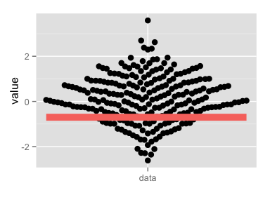

To test the null hypothesis, we consider the t-statistic $T = \frac{\bar{x}-\mu_0}{\text{SEM}}.$ **Intuition**: this t-statistic measures how many “standard errors” the sample mean is away from the (null) hypothesized mean.

**Formalism**: this statistic has the Student t-distribution $\text{Pr}(t)$ with $n-1$ **degrees of freedom**. The **p-value** is defined as the area under the curve where $|t|>|T|$.

**Note**: A common question is “*what exactly are degrees of freedom?*” The **number of degrees of freedom** is simply the number of values in the calculation of a statistic that are free to vary: for example, when calculating the t-statistic with $n$ data points, there are $n-1$ values that we can vary (and not $n$ values, as we have already calculated the mean from the sample).

**Example**: if the p-value $<0.05$, we conclude with $95\%$ confidence that $\mu \neq \mu_0$. In general, if the p-value $<\alpha$, then we can conclude with $100(1-\alpha)\%$ confidence that $\mu\neq\mu_0$. Below we plot the probability of seeing any given **effect size** ($=\bar{x}-\mu_0$), measured in standard deviations away from the (null) hypothesized mean, given $n=16$. I have also shaded in red the effect sizes that are not statistically significant at the $95$% confidence level.

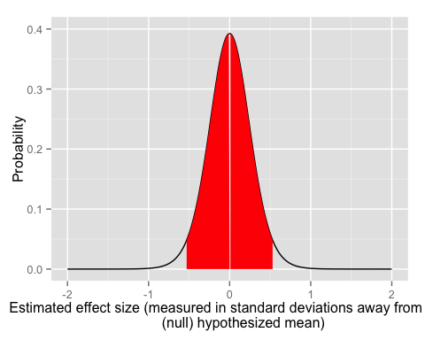

**Note**: This is a two-tailed t-test. A one-tailed t-test would, for example, have as the alternative hypothesis $H_1 : \mu > \mu_0$ and it is relatively rare. They are usually used when you have strong prior knowledge that $\mu \geq \mu_0$.

**Question**: Given $n=16$ data points, what is the minimum effect size $|\bar{x} - \mu_0|$ that you can detect at the $95\%$ confidence level (hint: look at the figure above)?

**Answer**: at the $95\%$ confidence level, we require that $T>2$ (actually a bit more); but $T =\frac{|\bar{x}-\mu_0|\sqrt{n}}{\sigma}$. Combining these and plugging in $n = 16$, we see that $|x - \mu_0| > \sigma/2$. In other words, with 16 data points, we can only detect effect sizes greater than half the standard deviation of the measurement error at the $95\%$ confidence level!

**Essential Note:** Due the Central Limit Theorem, the t-test does NOT require your data to be normally distributed. A general rule of thumb is that if your sample size $n>30$, then a t-test is appropriate (unless your data is highly skewed; for more, see [here](https://onlinecourses.science.psu.edu/stat414/node/261)).

**Exercise 2 (~20 minutes):**

Researchers claim that there is [*wisdom in crowds*](http://www.diplomacy.edu/resources/books/reviews/wisdom-crowds-why-many-are-smarter-few). Let’s test it! More specifically, the claim is that if you ask people to guess the number of jelly beans in a jar, the *average guess* should be pretty close to the *true mean*. So: each person in the room will guess the number of jelly beans. The exercise is to use a t-test to test the null hypothesis $H_0$ that the average guess is equal to $J$, the number of beans in the jar.

1. Record into R the guesses as a vector, along with the actual number of jelly beans;
2. Using write.csv(), save the data to a text file;
3. Using t.test(), perform a one sample t-test of the null hypothesis $H_0$ and interpret the result that R gives you.
4. Discuss whether the assumptions underlying the t-test are satisfied.

## 4.2 Welch’s t-test

In the one-sample t-test above, we tested whether there was a statistically significant effect when comparing an experiment to a known quantity $\mu_0$. Most of the time, we won’t know $\mu_0$, but we will have another dataset from a control experiment. In this case, we want to see whether or not there is a significant difference between the means of 2 sets of measurements $x_1 , x_2 , \ldots , x_n$ (control) & $y_1 , y_2 , \ldots , y_m$ (experiment).

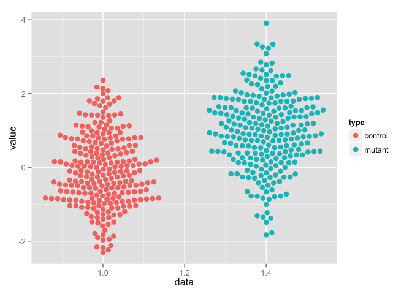

The t-statistic we use in this case is $T = \frac{|\bar{x} - \bar{y}|}{\sqrt{\text{SEM}_x^2 + \text{SEM}_y^2}}$ and the degrees of freedom $\nu$ is approximated by the *Welch-Satterthwaite equation*: $\nu \approx \frac{(\text{SEM}_x^2 + \text{SEM}_y^2)^2}{\text{SEM}_x^4/(n-1) + \text{SEM}_y^4/(n-1)}$

For further details, see

- Welch, B. L. (1947), “The generalization of student’s problem when several different population variances are involved.”, Biometrika 34: 28–35;
- *Mathematical Statistics and Data Analysis* by John A. Rice;
- https://en.wikipedia.org/wiki/Welch%27s_t_test.

**Exercise 3 (~15 minutes):**

1. Plot the microtubule lifetime data (mean $\pm$ standard error) as a function as tubulin concentration;
2. Perform t-tests for a variety of pairs of datasets at differing [Tb].

**Essential note**: If the population variances are same & so are the sample sizes, then we can do better! We can perform a two-sample t-test, which we describe now below:

## 4.3 Two sample t-test

The two-sample t-test assumes that the number of measurements are the same (i.e., $n=m$) and that the two distributions have the same variance (i.e., $\text{SD}_x = \text{SD}_y$). In this case, we can use all the measurements to estimate the underlying population variance such that $\text{SEM} = \sqrt{\text{SEM}_x^2 + \text{SEM}_y^2}/2$ and thus $T = \frac{2|\bar{x} - \bar{y}|}{\sqrt{\text{SEM}_x^2 + \text{SEM}_y^2}}.$

To quote Joe Howard’s *Statistical Inference and Models* notes for MB&B 435/635/ENAS518 - MATHEMATICAL METHODS IN BIOPHYSICS at Yale University, Fall 2013:

> Importantly, it could happen that the difference is significant by the unpaired t-test but not significant by the Welch test. This illustrates the general principle that the more assumption you make the more significant your results will be! The choice as to which one to use depends on how confident we are that the SDs are the same (i.e. how strong your expectation is). But generally it is better to make the minimum number of assumptions, and this is why the Welch test is preferred. Also, there are many cases where the variances of the two experiments are different - e.g. if you are measuring something using two different techniques.

## 4.4 Paired t-tests and Blocking

#### Paired t-test

In the wise words of Joe Howard, **“I recommend, whenever possible, designing experiments so you can use a paired t-test.”** Now why would he say this? Let’s see:

Well, a two-sample paired t-test is a regular two-sample t-test in which each $x_i$ (control) has a corresponding $y_i$ (experiment). The easiest way to achieve this is by performing the control and experiment together a number of times so that all conditions are the same for each $x_i$ and $y_i$ (besides the one variable corresponding to the experiment, e.g., a genetic knockdown). The you just use the one-sample t-test on the differences $\{x_i - y_i\}$ with the null hypothesis that $\mu_{X-Y}=0$. Boom!

#### Blocking & Randomized Block Design

There is not enough time in this Workshop to cover Blocking & Randomized Block Design BUT it is important that you know of its existence so I want to say a couple of words.

The intuition behind blocking is as follows: Let’s say that you do a bunch of controls and experiments under slightly different conditions (e.g. different days, labs, etc…) – then you want to ‘block’ together those done under similar conditions. There is a robust, statistical methodology set up for this. *Statistics for Experimenters* by Box, Hunter & Hunter (1978) is one particularly good reference for this material.

# 5 Correction Methods (E.g. the Bonferroni Correction)

**Problem**: When you are performing and comparing many experiments, there is a problem. For example, let’s take the case in which you have a control and then you perform an experiment that has no effect (a placebo) and you do it 20 times. We know that 5% of the time you will **randomly** get a statistically significant difference at the 95% confidence level (due to statistical fluctuations): this is one in 20 of your experiments giving you a *false positive* (also called a *type I error*)! We then need a stricter criterion for statistical significance: enter the **Bonferroni Correction**.

The **Bonferroni Correction**: let’s say that you are performing $N$ t-tests (with $N$ null hypotheses) and, for each, you require a confidence level of $1-\alpha$ ( 95% confidence means $\alpha = 0.05$). With the **Bonferroni correction**, we reject the null hypothesis at the $1-\alpha$ confidence level if $p<\alpha/N$ (as opposed to if $p<\alpha$, the uncorrected version of the t-test).

**Note**: this is a conservative test, in the sense that it is prone to rejecting the alternative hypothesis when the alternative hypothesis is true (that is, it can produce *false negatives*, also called *type II errors*). There are other, less conservative correction methods that you should check out if you need this in your research.

**Exercise 4 (~10 minutes)**: Perform t-tests on all 10 pairs of the microtubule datasets (i) without the Bonferroni correction & (ii) with the Bonferroni correction. Compare the results.

*Hint*: check out the function “pairwise.t.test”.

# 6 ANOVA & $F-$tests

**Motivation**: Plotted below is the ‘age at death from 3 different classes of society of Europeans’ (data from [here](http://www.stat.ufl.edu/~winner/datasets.html)):

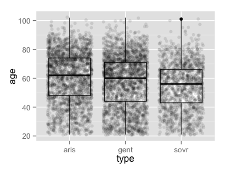

**Question**: The sample means of the groups are different but *is this difference statistically significant*? In other could the *between-group* variance arise statistically from the variance *within groups*? ANOVA provides a powerful method to answer such questions.

## 6.1 Example 1: ANOVA (analysis of variance).

#### Distinguishing multiple groups of numerical data with distinct means.

Let’s say that we have $n$ groups of data $M_i=\{D_{ij}\}_{j\in J}$, where $i\in\{1,\ldots ,n\}$, drawn from populations with respective *population means* $\alpha_1 , \alpha_2 , \ldots , \alpha_n$.

**Challenge**: Test the null hypothesis $H_0: \alpha_1 = \alpha_2 = \ldots = \alpha_n$.

**Solution**: Use the method of *analysis of variance* (ANOVA), which should really be called *analysis of the mean*.

**Note**: This is called **one-way ANOVA** as there is one *categorical variable* (or *factor*, indexed by $i$) that we are looking at.

**Intution**: The sample means $\bar{M}_i$ will be different. The real question is: could the *between-group* variance arise statistically purely from the variance *within groups*?

**Method**: To answer this, we look at the **F-statistic** which, intuitively, is

$F = \frac{\text{between-group variability}}{\text{within-group variability}}.$

The precise definition of the F-statistic is formulated in the Appendix accompanying these notes. Intuitively, if the F-statistic is large, then we can be fairly certain that we can reject the null hypothesis. Formally, we perform an **F-test** and retrieve a **p-value** (also see Appendix). To do so, we assume the statistical model

$D_{ij} = \alpha_{i} + \varepsilon_{ij},$

where the $\varepsilon_{ij}$ are Gaussian noise terms (all this means is that they are drawn from a Gaussian distribution).

**Example**: Age at death from 3 different classes of society of Europeans:

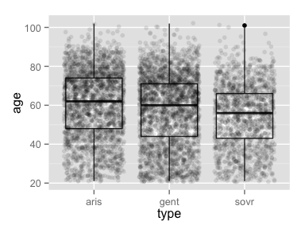

This is how we can perform ANOVA in R:

```r
aov.ex1 <- aov( age~type , data) # perform the ANOVA
summary(aov.ex1) #summarize the results of the ANOVA
```

```
##               Df  Sum Sq Mean Sq F value Pr(>F)
## type           2   32392   16196   53.76 <2e-16 ***
## Residuals   6183 1862626     301
## ---
## Signif. codes:  0 '***' 0.001 '**' 0.01 '*' 0.05 '.' 0.1 ' ' 1
```

```r
print(model.tables(aov.ex1,"means"),digits=3)       #report the means and the number of subjects/cell
```

```
## Tables of means
## Grand mean
##
## 57.67556
##
##  type
##       aris   gent   sovr
##       60.2   57.3   54.2
## rep 2291.0 2455.0 1440.0
```

**Exercise 5 (~5 minutes)**: Interpret and discuss the above output.

**Problem**: if the null hypothesis is rejected, we do not know which $\alpha_i$’s are different from each other. There are *post hoc* methods to deal with this that we shall not delve into here. Suffice to say, this is an interesting & important field of statistics & experimental design known as [*post hoc analysis*](https://en.wikipedia.org/wiki/Post_hoc_analysis).

**Note**: When $n=2$, such a one-way ANOVA reduces to a t-test.

## 6.2 Example 2: basic two-way ANOVA for gene expression levels (bioinoformatics)

We will consider the example from (Pavladis, 2003), *Using ANOVA for gene selection from microarray studies of the nervous system.*

In such a two-way ANOVA, the expression level of a gene is given by

$E_{ijk} = T_i + S_j + (T\cdot S)_{ij} + \varepsilon_{ijk},$

$E_{13k} = T_1 + S_3 + (T\cdot S)_{13} + \varepsilon_{13k},$ Note that it is still a linear model and has three *effect* terms: *main effects* $T$ & $S$ and an *interaction effect* $T\cdot S$. When performing ANOVA in such a study, we get three F-statistics and thus three p-values for each gene: one for each of the possible effects. This same model is fitted to all genes and then, for each effect, we can rank the genes by strength of the effect in question.

To quote (Pavladis, 2003) at some length,

> The file sandberg-sampledata.txt contains data for 1000 genes measured using one- channel oligonucleotide arrays (out of the >11,000 in the original data set)…This data set contains 24 samples (microarrays), with two mouse strains tested (129 and B6), and six brain regions: amygdala (ag), cerebellum (cb), cortex (cx), entorhinal cortex (ec), hippocampus (hp), and midbrain (mb). Two replicates were performed for each region in each strain [9]. This is a balanced two-way design with high-quality data, though with fewer replicates per group than one would like in order to sensitively detect interaction effects. The factors are strain and region, with levels 129/B6 and ag/cb/cx/ec/hp/mb, respectively. We are interested in identifying genes which are differentially expressed between strains, regions, and those which show interactions between strain and region. An example of the latter would be a gene that is expressed at high levels in the cerebellum of 129 mice, but at low levels in B6 cerebellum, compared to other regions.

**Exercise 6 (~20 minutes)**:

1. Import “sandberg-sampledata.txt” as a dataframe called ‘data’– to do so, check out the function ‘read.table’ and look specifically at the arguments ‘header’ and ‘row.names’ – you may also like to look at the file in a text editor and see whether there are column names (header) and/or row names.

```r
help(read.table)
```

2. Select any row (gene) and figure out what the data means;
3. Run the following code and figure out what it does:

```r
strain <- gl(2,12,24, label=c("129","bl6"))
region <- gl(6,2,24, label=c("ag", "cb", "cx", "ec", "hp", "mb"))
add_factors <- function(x) {
  m<-data.frame(strain,region, x);
}
df <- apply(data , 1 , add_factors)
```

4. Perform ANOVA on a single gene and output/summarize the result;
5. Use ‘apply’ OR a ‘for loop’ to perform ANOVA on all genes!
6. Write all the p-values to a .txt and save it for later use; in the code chunk here I have saved the p-values to a dataframe: all you need to do is write it to a .txt;

```r
anova_res <- lapply( anovaresults , anova)
pvalues<-data.frame( lapply(anova_res, function(x) { x["Pr(>F)"][1:3,] }) )
```

7. A common question in bioinformatics is to see which genes’ expression levels are most effected by, for example, the region in the brain we are looking at: to this end, rank the genes in order of strength of effect of the main effect term $T$.

## 6.3 Example 4: testing for multimodality.

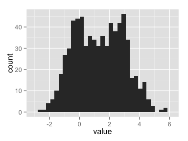

Is the population from which I have drawn the above data $X$ unimodal or multimodal? It may look bimodal, however an apparent 2nd peak can appear due to statistical fluctuations and sampling error. This question is very important because the answer could, for example, tell us that we actually have two distinct sub-populations.

Algorithm:

1. Bin the data;
2. Compute the variance $Var_X = Var(X)$ of the data;
3. For each bin (indexed by $i$), divide the data into two sub-population $X_{i1},X_{i2}$, separated by the end point of the bin. Compute the mean variance $Var_i = (Var(X_{i1}) + Var(X_{i2}))/2$;
4. Pick the decomposition of $X$ that minimizes $Var_i$;
5. Compute the F-statistic $F=\text{min}(Var_i)/Var_i$;
6. Compute the p-value, given $F$ and $(1,n+m-2)$ degrees of freedom, where $n$ and $m$ are the respective sizes of the sub-populations in the decomposition that minimizes $Var_i$.

For more, see Larkin R. P. (1979). An algorithm for assessing bimodality vs. unimodality in a univariate distribution. Behav. Res. Methods Instrum. 11, 467–468.

# 7 References

- Welch, B. L. (1947), “The generalization of student’s problem when several different population variances are involved.”, Biometrika 34: 28–35;
- *Mathematical Statistics and Data Analysis* by John A. Rice (1988), *Duxbury Press*;
- *Statistics for Experimenters* by Box, Hunter & Hunter (1978), *Wiley & Sons*;
- *Using ANOVA for gene selection from microarray studies of the nervous system*, P. Pavladis, Methods. 2003 31(4):282-9;
- *Think Stats* by Allen Downey (2011), *O’Reilly Media* ([.pdf here](http://greenteapress.com/thinkstats/));
- *Understanding The New Statistics: Effect Sizes, Confidence Intervals, and Meta-Analysis* by Geoff Cumming (2011), *Routledge*;
- *Data Reduction and Error Analysis for the Physical Sciences* by Philip Bevington & D. Keith Robinson (2002), *McGraw-Hill Education*.
- Larkin R. P. (1979). An algorithm for assessing bimodality vs. unimodality in a univariate distribution. Behav. Res. Methods Instrum. 11, 467–468.
- Gardner MK, Zanic M, Gell C, Bormuth V, et al. 2011. Depolymerizing kinesins Kip3 and MCAK shape cellular microtubule architecture by differential control of catastrophe. Cell 147: 1092– 103.